# Federal Education Spending vs. Student Outcomes

Nina Ysabel Alinsonorin

2025-11-30

**Introduction** This project investigates whether increases in federal education spending are associated with changes in student outcomes at the state level over time. While federal funding plays an essential role in supporting public education (particularly for high-need and historically underserved populations) it remains unclear whether fluctuations in federal investment translate into measurable shifts in states’ educational systems. In this analysis, student enrollment serves as a broad indicator of system participation and access, allowing us to examine whether federal dollars correspond to changes in the size of each state’s public school population.

By combining federal revenue data with annual state-level enrollment counts, this project evaluates how federal support and student outcomes evolve together and whether funding increases are meaningfully linked to enrollment growth. This approach offers insight into the extent to which federal policy influences state education systems and helps clarify whether federal investment aligns with shifts in demand, capacity, and participation across the United States.

**Initial Data Retrieval/Cleaning** To prepare the dataset for analysis, the raw state-level education finance files were first downloaded individually from the National Center for Education Statistics (NCES) website. Because the files varied in structure, formatting, and column naming conventions across years, the necessary variables (such as state_fips, state, federal_revenue, total_revenue, enrollment, and year) were manually identified and renamed within each file to ensure consistency. All files were then converted into standardized CSV format and stored within a unified data directory.

A streamlined R workflow was used to read each file as character data, merge them into a single dataset, and normalize column names for uniformity across years. Only the essential variables required for analysis were retained, resulting in a harmonized dataset suitable for examining long-term trends in federal education finance at the state level.

Note: During development, the knitr::root.dir method for setting the working directory did not function correctly in the knitted R Markdown environment. As a temporary workaround, the working directory was manually set within each code chunk to ensure the files would load properly. This is still a work in progress, and future refinements aim to fully integrate an automated root directory specification for smoother reproducibility.

```r
setwd("~/Downloads/edu_finance_project/data_raw")

library(readr)
library(dplyr)
library(purrr)
library(janitor)
```

```r
files <- list.files(pattern = "^stfis_\\d{4}\\.csv$")

df_list <- map(files, ~ read_csv(
  .x,
  col_types = cols(.default = col_character())
))
# Merge all files
merged_df <- bind_rows(df_list)

# Clean names
merged_df <- merged_df %>%
  janitor::clean_names()

# ⭐ ONLY KEEP THE COLUMNS NEEDED — DO NOT TOUCH VALUES ⭐
merged_df <- merged_df %>%
  select(
    year,
    state_fips,
    stabr,
    state,
    total_revenue,
    federal_revenue,
    enrollment
  )

head(merged_df)
```

```
## # A tibble: 6 × 7
##   year  state_fips stabr state      total_revenue federal_revenue enrollment
##   <chr> <chr>      <chr> <chr>      <chr>         <chr>           <chr>
## 1 <NA>  <NA>       <NA>  <NA>       <NA>          <NA>            <NA>
## 2 2000  1          AL    Alabama    215,166,870   1,880,267,638   740732
## 3 2000  2          AK    Alaska     50,076,306    450,803,336     134391
## 4 2000  4          AZ    Arizona    144,012,629   1,787,356,212   852612
## 5 2000  5          AR    Arkansas   109,553,367   1,084,819,850   451034
## 6 2000  6          CA    California 977,532,258   17,023,740,804  6038590
```

**EDA**

```r
setwd("~/Downloads/edu_finance_project/data_raw")
summary(merged_df)
```

```
##      year            state_fips           stabr              state
##  Length:1434        Length:1434        Length:1434        Length:1434
##  Class :character   Class :character   Class :character   Class :character
##  Mode  :character   Mode  :character   Mode  :character   Mode  :character
##  total_revenue      federal_revenue     enrollment
##  Length:1434        Length:1434        Length:1434
##  Class :character   Class :character   Class :character
##  Mode  :character   Mode  :character   Mode  :character
```

*EDA at the National Level*

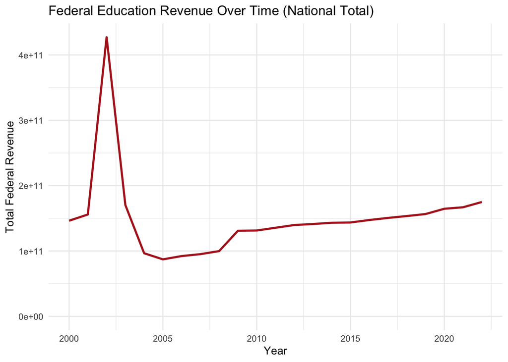

```r
setwd("~/Downloads/edu_finance_project/data_raw")
# Create numeric-only version for national plots
merged_numeric <- merged_df %>%
  mutate(
    year = as.numeric(year),
    total_revenue = as.numeric(gsub(",", "", total_revenue)),
    federal_revenue = as.numeric(gsub(",", "", federal_revenue)),
    enrollment = as.numeric(gsub(",", "", enrollment))
  )
library(ggplot2)
library(dplyr)

# Federal Revenue Over Time
national_fed <- merged_numeric %>%
  group_by(year) %>%
  summarize(federal_revenue_total = sum(federal_revenue, na.rm = TRUE))

ggplot(national_fed, aes(x = year, y = federal_revenue_total)) +
  geom_line(color = "firebrick", linewidth = 1) +
  labs(
    title = "Federal Education Revenue Over Time (National Total)",
    x = "Year",
    y = "Total Federal Revenue"
  ) +
  theme_minimal()
```

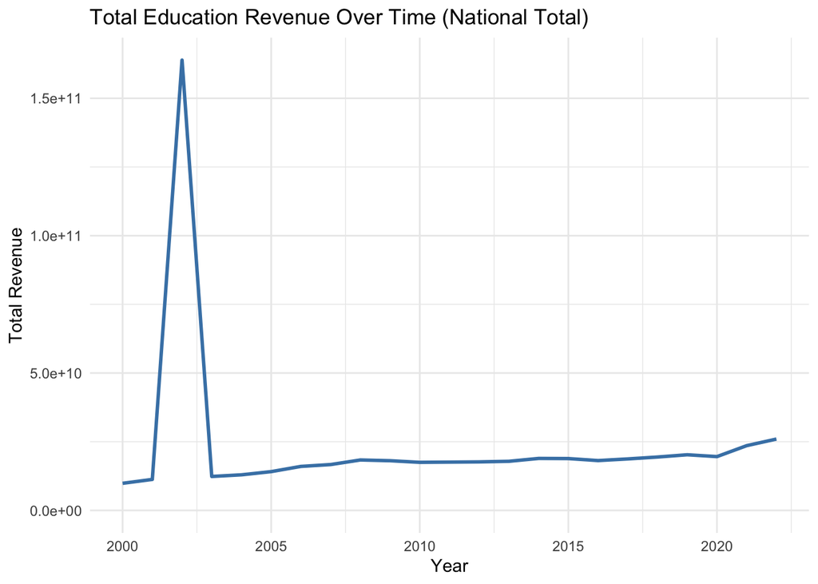

```r
# Total Revenue Over Time
national_total <- merged_numeric %>%
  group_by(year) %>%
  summarize(total_revenue_total = sum(total_revenue, na.rm = TRUE))

ggplot(national_total, aes(x = year, y = total_revenue_total)) +
  geom_line(color = "steelblue", linewidth = 1) +
  labs(
    title = "Total Education Revenue Over Time (National Total)",
    x = "Year",
    y = "Total Revenue"
  ) +
  theme_minimal()
```

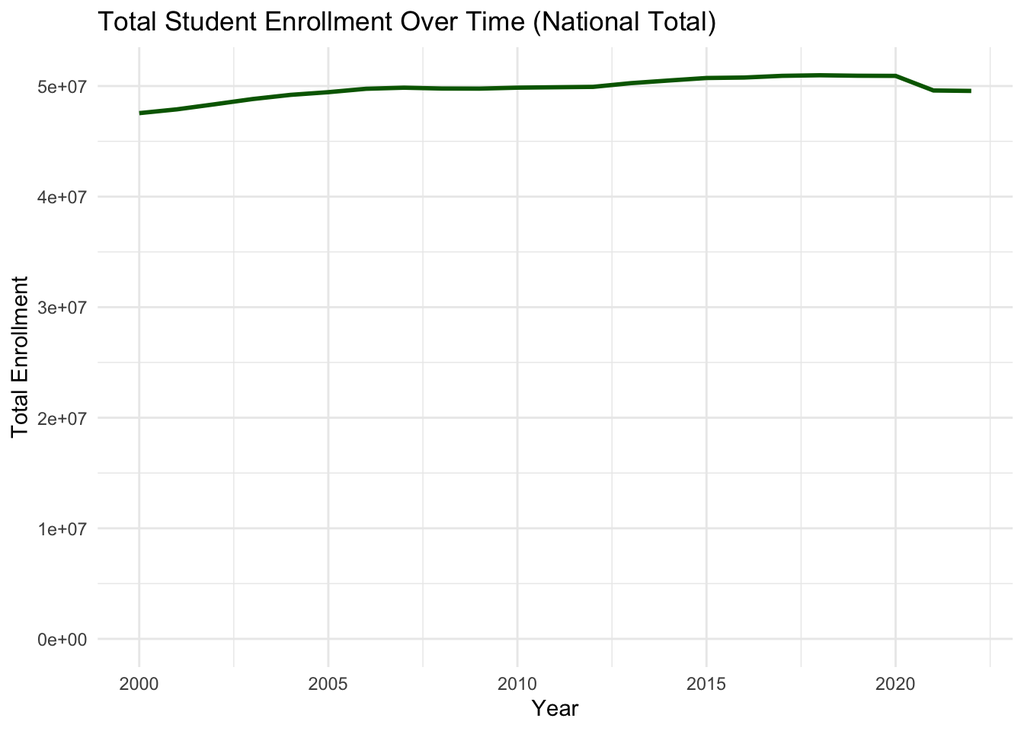

```r
#Enrollment Over Time
national_enroll <- merged_numeric %>%
  group_by(year) %>%
  summarize(total_enrollment = sum(enrollment, na.rm = TRUE))

ggplot(national_enroll, aes(x = year, y = total_enrollment)) +
  geom_line(color = "darkgreen", linewidth = 1) +
  labs(
    title = "Total Student Enrollment Over Time (National Total)",
    x = "Year",
    y = "Total Enrollment"
  ) +
  theme_minimal()
```

The national enrollment trend shows steady and gradual growth from 2000 to around 2017, where it peaks just above 51 million students before declining slightly after 2020. This suggests relatively stable student population levels over the two decades, with only a small drop in the most recent years, likely reflecting demographic shifts or pandemic-related enrollment disruptions.

In contrast, both total revenue and federal revenue display a dramatic spike around 2002, followed by an immediate drop and then stabilization. This large spike is almost certainly caused by an anomaly or reporting change in the underlying dataset rather than a real-world funding surge. After the spike, total revenue slowly increases over time, while federal revenue remains lower in the mid-2000s before rising gradually beginning around 2009. The upward trend in federal revenue from roughly 2010 onward likely reflects expansions in federal support after economic downturns and ongoing education policy investments.

*EDA at the State Level*

```
## `geom_line()`: Each group consists of only one observation.
## ℹ Do you need to adjust the group aesthetic?
```

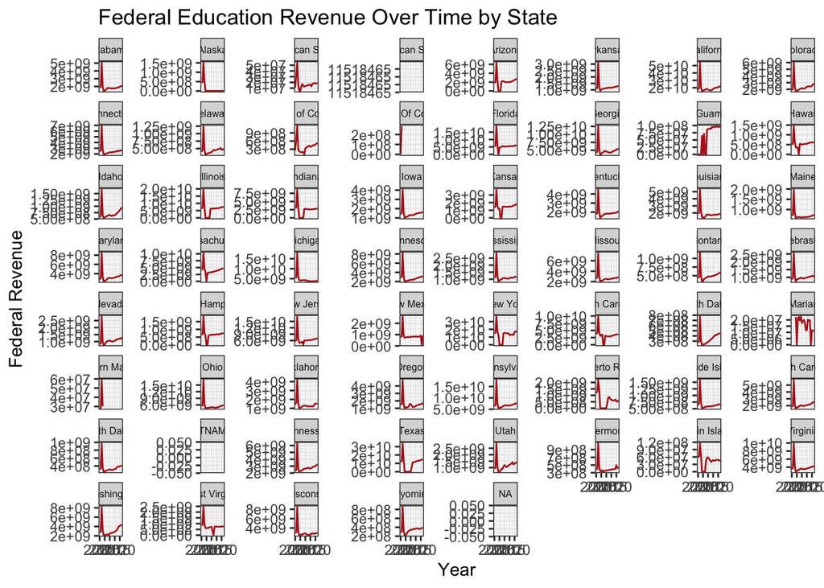

```r
setwd("~/Downloads/edu_finance_project/data_raw")

library(ggplot2)
library(dplyr)

# State Federal Revenue Over Time
state_fed <- merged_numeric %>%
  group_by(state, year) %>%
  summarize(federal_revenue = sum(federal_revenue, na.rm = TRUE))
ggplot(state_fed, aes(x = year, y = federal_revenue)) +
  geom_line(color = "firebrick") +
  facet_wrap(~ state, scales = "free_y") +
  labs(
    title = "Federal Education Revenue Over Time by State",
    x = "Year",
    y = "Federal Revenue"
  ) +
  theme_bw() +
  theme(strip.text = element_text(size = 6))
```

```r
# State Total Revenue Over Time
state_total <- merged_numeric %>%
  group_by(state, year) %>%
  summarize(total_revenue = sum(total_revenue, na.rm = TRUE))
```

```
## `geom_line()`: Each group consists of only one observation.
## ℹ Do you need to adjust the group aesthetic?
```

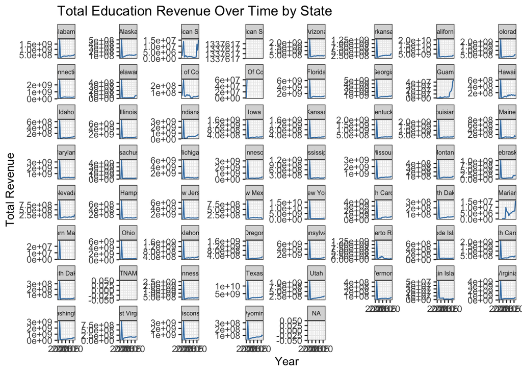

```r
ggplot(state_total, aes(x = year, y = total_revenue)) +
  geom_line(color = "steelblue") +
  facet_wrap(~ state, scales = "free_y") +
  labs(
    title = "Total Education Revenue Over Time by State",
    x = "Year",
    y = "Total Revenue"
  ) +
  theme_bw() +
  theme(strip.text = element_text(size = 6))
```

```r
# State Enrollment Over Time
state_enroll <- merged_numeric %>%
  group_by(state, year) %>%
  summarize(enrollment = sum(enrollment, na.rm = TRUE))
```

```
## `geom_line()`: Each group consists of only one observation.
## ℹ Do you need to adjust the group aesthetic?
```

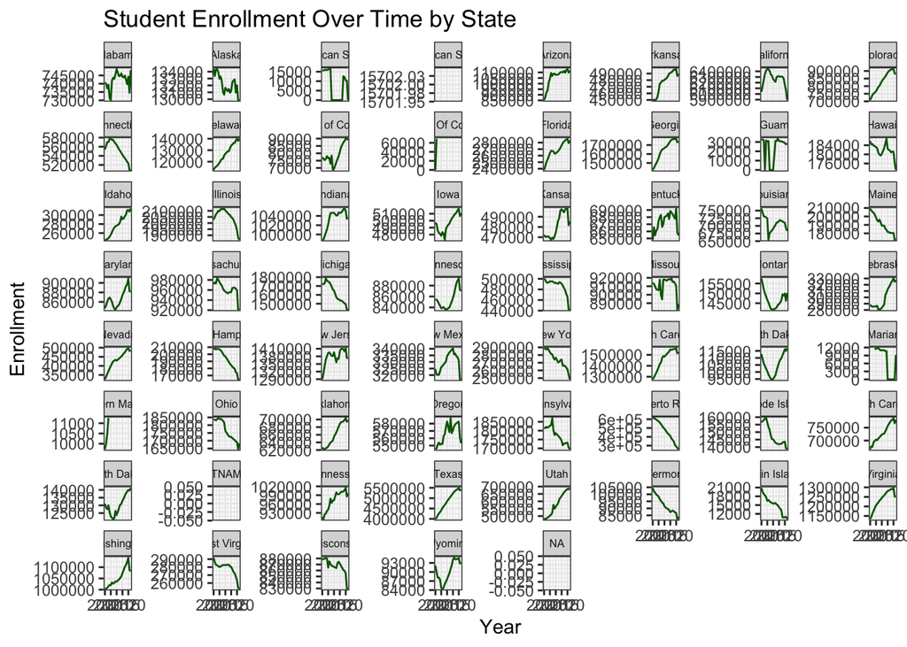

```r
ggplot(state_enroll, aes(x = year, y = enrollment)) +
  geom_line(color = "darkgreen") +
  facet_wrap(~ state, scales = "free_y") +
  labs(
    title = "Student Enrollment Over Time by State",
    x = "Year",
    y = "Enrollment"
  ) +
  theme_bw() +
  theme(strip.text = element_text(size = 6))
```

Across states, student enrollment generally shows slow and steady growth from 2000 through the mid-2010s, followed by modest declines in many states after 2017. While most states follow this pattern, a few (such as Florida, Texas, and Utah) show continued increases, reflecting population growth, whereas states like Michigan, New York, and Illinois experience noticeable long-term declines.

Total education revenue varies widely by state, with consistently higher levels in large states like California, Texas, and New York compared to smaller or less populous states. Most states show gradual revenue growth over the two decades, though the extreme spikes in the early 2000s echo the national anomalies and likely reflect changes in reporting rather than true funding surges.

Federal revenue also grows across most states, with a notable rise beginning around 2009, which aligns with national increases in federal support during economic recovery periods. Smaller states such as Wyoming, North Dakota, and Vermont show more volatility year-to-year, while larger states exhibit smoother and more stable trends. Overall, the state-level plots demonstrate that both funding and enrollment shifts differ substantially across the country, underscoring the importance of analyzing federal investment not only nationally but also in relation to state-specific demographic and fiscal context.

**Analysis**

*Frequentist Linear Regression*

```r
setwd("~/Downloads/edu_finance_project/data_raw")
## Frequentist Analysis: Relationship between Federal Revenue and Enrollment

library(dplyr)

# Create state-year analysis dataset from merged_numeric
analysis_df <- merged_numeric %>%
  select(state, year, federal_revenue, total_revenue, enrollment) %>%
  filter(
    !is.na(year),
    !is.na(federal_revenue),
    !is.na(enrollment)
  ) %>%
  # rescale for easier interpretation
  mutate(
    federal_rev_bil = federal_revenue / 1e9,   # billions of dollars
    total_rev_bil   = total_revenue   / 1e9,   # billions of dollars
    enrollment_mil  = enrollment      / 1e6    # millions of students
  )

summary(analysis_df)
```

```
##     state                year      federal_revenue      total_revenue
##  Length:1231        Min.   :2000   Min.   :-1.000e+00   Min.   :-1.000e+00
##  Class :character   1st Qu.:2005   1st Qu.: 5.415e+08   1st Qu.: 7.040e+07
##  Mode  :character   Median :2012   Median : 1.442e+09   Median : 2.052e+08
##                     Mean   :2011   Mean   : 2.694e+09   Mean   : 4.306e+08
##                     3rd Qu.:2017   3rd Qu.: 3.042e+09   3rd Qu.: 3.941e+08
##                     Max.   :2022   Max.   : 5.397e+10   Max.   : 2.016e+10
##    enrollment      federal_rev_bil   total_rev_bil     enrollment_mil
##  Min.   :     -1   Min.   : 0.0000   Min.   : 0.0000   Min.   :-0.000001
##  1st Qu.: 181613   1st Qu.: 0.5415   1st Qu.: 0.0704   1st Qu.: 0.181613
##  Median : 578947   Median : 1.4420   Median : 0.2052   Median : 0.578947
##  Mean   : 889778   Mean   : 2.6940   Mean   : 0.4306   Mean   : 0.889778
##  3rd Qu.:1035210   3rd Qu.: 3.0424   3rd Qu.: 0.3941   3rd Qu.: 1.035210
##  Max.   :6441557   Max.   :53.9717   Max.   :20.1612   Max.   : 6.441557
```

The analysis dataset includes 1,231 state–year observations from 2000 to 2022. Federal revenue, total revenue, and enrollment all show wide variation across states, with the average state receiving roughly $2.7 billion in federal education funding and reporting an average of 0.89 million students enrolled per year. The distributions are highly skewed, as reflected in the large gap between the medians and maximum values, driven by large states such as California, Texas, and New York. After rescaling the variables into billions (revenue) and millions (enrollment), the transformed variables retain the same overall shape but are easier to interpret in the regression analysis. The presence of some values close to zero suggests potential reporting anomalies in certain states and years, but the overall structure of the dataset remains suitable for modeling the relationship between federal education revenue and student enrollment.

```r
setwd("~/Downloads/edu_finance_project/data_raw")
## Model 1: Enrollment ~ Federal Revenue (national state-year panel)

model1 <- lm(enrollment_mil ~ federal_rev_bil, data = analysis_df)

summary(model1)
```

```
##
## Call:
## lm(formula = enrollment_mil ~ federal_rev_bil, data = analysis_df)
##
## Residuals:
##     Min      1Q  Median      3Q     Max
## -5.8136 -0.2667 -0.0988  0.0732  4.5474
##
## Coefficients:
##                 Estimate Std. Error t value Pr(>|t|)
## (Intercept)     0.302843   0.023034   13.15   <2e-16 ***
## federal_rev_bil 0.217864   0.004722   46.14   <2e-16 ***
## ---
## Signif. codes:  0 '***' 0.001 '**' 0.01 '*' 0.05 '.' 0.1 ' ' 1
##
## Residual standard error: 0.6738 on 1229 degrees of freedom
## Multiple R-squared:  0.634,  Adjusted R-squared:  0.6337
## F-statistic:  2129 on 1 and 1229 DF,  p-value: < 2.2e-16
```

```r
confint(model1)
```

```
##                     2.5 %    97.5 %
## (Intercept)     0.2576517 0.3480340
## federal_rev_bil 0.2085996 0.2271275
```

```r
## Model 2: Enrollment ~ Federal Revenue + Year + State fixed effects

model2 <- lm(enrollment_mil ~ federal_rev_bil + year + factor(state),
             data = analysis_df)

summary(model2)
```

```
##
## Call:
## lm(formula = enrollment_mil ~ federal_rev_bil + year + factor(state),
##     data = analysis_df)
##
## Residuals:
##      Min       1Q   Median       3Q      Max
## -0.84515 -0.01404  0.00112  0.01905  0.61702
##
## Coefficients:
##                                         Estimate Std. Error t value Pr(>|t|)
## (Intercept)                           -3.3151284  0.7092243  -4.674 3.29e-06
## federal_rev_bil                        0.0005415  0.0010874   0.498 0.618592
## year                                   0.0020168  0.0003525   5.721 1.34e-08
## factor(state)Alaska                   -0.6086005  0.0251906 -24.160  < 2e-16
## factor(state)American Samoa           -0.7341858  0.0254972 -28.795  < 2e-16
## factor(state)American Somoa           -0.7048583  0.0852656  -8.267 3.70e-16
## factor(state)Arizona                   0.3132634  0.0251138  12.474  < 2e-16
## factor(state)Arkansas                 -0.2637385  0.0251249 -10.497  < 2e-16
## factor(state)California                5.5147293  0.0318932 172.912  < 2e-16
## factor(state)Colorado                  0.0881490  0.0251180   3.509 0.000466
## factor(state)Connecticut              -0.1907153  0.0251224  -7.591 6.44e-14
## factor(state)Delaware                 -0.6136253  0.0251652 -24.384  < 2e-16
## factor(state)District of Columbia     -0.6622066  0.0254679 -26.002  < 2e-16
## factor(state)District Of Columbia     -0.6517832  0.0852584  -7.645 4.35e-14
## factor(state)Florida                   1.9366229  0.0254763  76.017  < 2e-16
## factor(state)Georgia                   0.9050347  0.0253263  35.735  < 2e-16
## factor(state)Guam                     -0.7184455  0.0254931 -28.182  < 2e-16
## factor(state)Hawaii                   -0.5591322  0.0251592 -22.224  < 2e-16
## factor(state)Idaho                    -0.4623597  0.0251486 -18.385  < 2e-16
## factor(state)Illinois                  1.3013299  0.0254701  51.092  < 2e-16
## factor(state)Indiana                   0.2913867  0.0251183  11.601  < 2e-16
## factor(state)Iowa                     -0.2451698  0.0251180  -9.761  < 2e-16
## factor(state)Kansas                   -0.2599881  0.0251190 -10.350  < 2e-16
## factor(state)Kentucky                 -0.0683927  0.0251134  -2.723 0.006558
## factor(state)Louisiana                -0.0330173  0.0251135  -1.315 0.188860
## factor(state)Maine                    -0.5509149  0.0251488 -21.906  < 2e-16
## factor(state)Maryland                  0.1254463  0.0251581   4.986 7.08e-07
## factor(state)Massachusetts             0.2187474  0.0252115   8.677  < 2e-16
## factor(state)Michigan                  0.8752317  0.0253092  34.582  < 2e-16
```

[output cut: 85 more lines]

```
## factor(state)Texas                    ***
## factor(state)Utah                     ***
## factor(state)Vermont                  ***
## factor(state)Virgin Islands           ***
## factor(state)Virginia                 ***
## factor(state)Washington               ***
## factor(state)West Virginia            ***
## factor(state)Wisconsin                ***
## factor(state)Wyoming                  ***
## ---
## Signif. codes:  0 '***' 0.001 '**' 0.01 '*' 0.05 '.' 0.1 ' ' 1
##
## Residual standard error: 0.08329 on 1170 degrees of freedom
## Multiple R-squared:  0.9947, Adjusted R-squared:  0.9944
## F-statistic:  3642 on 60 and 1170 DF,  p-value: < 2.2e-16
```

```r
confint(model2)
```

```
##                                              2.5 %       97.5 %
## (Intercept)                           -4.706621890 -1.923634908
## federal_rev_bil                       -0.001592012  0.002675046
## year                                   0.001325185  0.002708481
## factor(state)Alaska                   -0.658024316 -0.559176654
## factor(state)American Samoa           -0.784211114 -0.684160489
## factor(state)American Somoa           -0.872148931 -0.537567742
## factor(state)Arizona                   0.263990214  0.362536535
## factor(state)Arkansas                 -0.313033424 -0.214443530
## factor(state)California                5.452155025  5.577303528
## factor(state)Colorado                  0.038867655  0.137430290
## factor(state)Connecticut              -0.240005235 -0.141425362
## factor(state)Delaware                 -0.662999326 -0.564251217
## factor(state)District of Columbia     -0.712174550 -0.612238689
## factor(state)District Of Columbia     -0.819059547 -0.484506776
## factor(state)Florida                   1.886638546  1.986607341
## factor(state)Georgia                   0.855344784  0.954724708
## factor(state)Guam                     -0.768462663 -0.668428256
## factor(state)Hawaii                   -0.608494382 -0.509769997
## factor(state)Idaho                    -0.511701064 -0.413018420
## factor(state)Illinois                  1.251357631  1.351302144
## factor(state)Indiana                   0.242104786  0.340668645
## factor(state)Iowa                     -0.294451129 -0.195888497
## factor(state)Kansas                   -0.309271462 -0.210704733
## factor(state)Kentucky                 -0.117665005 -0.019120375
## factor(state)Louisiana                -0.082289824  0.016255153
## factor(state)Maine                    -0.600256616 -0.501573089
## factor(state)Maryland                  0.076086326  0.174806347
## factor(state)Massachusetts             0.169282682  0.268212216
## factor(state)Michigan                  0.825575139  0.924888267
## factor(state)Minnesota                 0.063923771  0.162547448
## factor(state)Mississippi              -0.305169128 -0.206566800
## factor(state)Missouri                  0.118360909  0.216968315
## factor(state)Montana                  -0.643330484 -0.544594652
## factor(state)Nebraska                 -0.490164922 -0.391544995
## factor(state)Nevada                   -0.359321118 -0.260712811
## factor(state)New Hampshire            -0.598563168 -0.499866925
## factor(state)New Jersey                0.583474573  0.683943086
## factor(state)New Mexico               -0.461295983 -0.362643447
## factor(state)New York                  1.937641809  2.046967753
## factor(state)North Carolina            0.670009127  0.768737477
## factor(state)North Dakota             -0.685021524 -0.586242570
## factor(state)Northern Mariana Islands -0.790387919 -0.686153753
## factor(state)Northern Marianas        -0.800389107 -0.622042344
## factor(state)Ohio                      0.973402999  1.073210864
## factor(state)Oklahoma                 -0.129159702 -0.030591706
## factor(state)Oregon                   -0.225057016 -0.126496700
## factor(state)Pennsylvania              0.979970566  1.080971450
## factor(state)Puerto Rico              -0.328257111 -0.229546966
## factor(state)Rhode Island             -0.642644755 -0.543946420
## factor(state)South Carolina           -0.060564165  0.037987234
## factor(state)South Dakota             -0.659800992 -0.561023096
## factor(state)Tennessee                 0.180614826  0.279232103
## factor(state)Texas                     4.059875953  4.163882155
## factor(state)Utah                     -0.207594932 -0.108995722
## factor(state)Vermont                  -0.697762624 -0.599001691
## factor(state)Virgin Islands           -0.775067458 -0.676189080
## factor(state)Virginia                  0.443564878  0.542481644
## factor(state)Washington                0.262704193  0.361392909
## factor(state)West Virginia            -0.513003949 -0.414333449
## factor(state)Wisconsin                 0.074629458  0.173279038
## factor(state)Wyoming                  -0.700085462 -0.601307003
```

*Bayesian*

```r
setwd("~/Downloads/edu_finance_project/data_raw")
library(MCMCpack)
library(coda)
library(dplyr)

# Use the same analysis dataset from frequentist section

bayes_df <- analysis_df %>%
  as.data.frame() %>%
  dplyr::select(enrollment_mil, federal_rev_bil, year, state)
```

Enrollment - Federal Revenue Only

```r
setwd("~/Downloads/edu_finance_project/data_raw")
# Bayesian simple linear regression
bayes_model1 <- MCMCregress(
  enrollment_mil ~ federal_rev_bil,
  data = bayes_df,
  burnin = 5000,
  mcmc = 20000,
  thin = 10,
  verbose = FALSE
)

summary(bayes_model1)
```

```
##
## Iterations = 5001:24991
## Thinning interval = 10
## Number of chains = 1
## Sample size per chain = 2000
##
## 1. Empirical mean and standard deviation for each variable,
##    plus standard error of the mean:
##
##                   Mean      SD  Naive SE Time-series SE
## (Intercept)     0.3029 0.02288 0.0005117      0.0005117
## federal_rev_bil 0.2178 0.00481 0.0001076      0.0001076
## sigma2          0.4547 0.01841 0.0004117      0.0004117
##
## 2. Quantiles for each variable:
##
##                   2.5%    25%    50%    75%  97.5%
## (Intercept)     0.2585 0.2878 0.3027 0.3182 0.3484
## federal_rev_bil 0.2085 0.2144 0.2178 0.2211 0.2274
## sigma2          0.4197 0.4422 0.4539 0.4671 0.4907
```

```r
HPDinterval(bayes_model1)
```

```
##                     lower     upper
## (Intercept)     0.2581591 0.3479564
## federal_rev_bil 0.2088130 0.2274643
## sigma2          0.4189924 0.4887442
## attr(,"Probability")
## [1] 0.95
```

Year and State Fixed Effects

```r
setwd("~/Downloads/edu_finance_project/data_raw")
# Bayesian regression with controls
bayes_model2 <- MCMCregress(
  enrollment_mil ~ federal_rev_bil + year + factor(state),
  data = bayes_df,
  burnin = 5000,
  mcmc = 20000,
  thin = 10,
  verbose = FALSE
)

summary(bayes_model2)
```

```
##
## Iterations = 5001:24991
## Thinning interval = 10
## Number of chains = 1
## Sample size per chain = 2000
##
## 1. Empirical mean and standard deviation for each variable,
##    plus standard error of the mean:
##
##                                             Mean        SD  Naive SE
## (Intercept)                           -3.3153429 0.7011100 1.568e-02
## federal_rev_bil                        0.0005694 0.0010519 2.352e-05
## year                                   0.0020171 0.0003483 7.789e-06
## factor(state)Alaska                   -0.6088499 0.0253901 5.677e-04
## factor(state)American Samoa           -0.7349305 0.0251330 5.620e-04
## factor(state)American Somoa           -0.7054928 0.0848491 1.897e-03
## factor(state)Arizona                   0.3135744 0.0244215 5.461e-04
## factor(state)Arkansas                 -0.2644459 0.0250820 5.608e-04
## factor(state)California                5.5136789 0.0308352 6.895e-04
## factor(state)Colorado                  0.0868227 0.0252349 5.643e-04
## factor(state)Connecticut              -0.1910849 0.0249698 5.583e-04
## factor(state)Delaware                 -0.6133641 0.0243354 5.442e-04
## factor(state)District of Columbia     -0.6627666 0.0249095 5.570e-04
## factor(state)District Of Columbia     -0.6541612 0.0854200 1.910e-03
## factor(state)Florida                   1.9360014 0.0257490 5.758e-04
## factor(state)Georgia                   0.9047444 0.0253347 5.665e-04
## factor(state)Guam                     -0.7185115 0.0254503 5.691e-04
## factor(state)Hawaii                   -0.5599912 0.0252774 5.652e-04
## factor(state)Idaho                    -0.4634034 0.0253437 5.667e-04
## factor(state)Illinois                  1.3009805 0.0255791 5.720e-04
## factor(state)Indiana                   0.2909431 0.0248682 5.561e-04
## factor(state)Iowa                     -0.2451214 0.0250176 5.594e-04
## factor(state)Kansas                   -0.2607674 0.0253190 5.662e-04
## factor(state)Kentucky                 -0.0685135 0.0240174 5.370e-04
## factor(state)Louisiana                -0.0339408 0.0247569 5.536e-04
## factor(state)Maine                    -0.5514587 0.0259064 5.793e-04
## factor(state)Maryland                  0.1245759 0.0244767 5.473e-04
## factor(state)Massachusetts             0.2187191 0.0256833 5.743e-04
## factor(state)Michigan                  0.8745409 0.0256339 5.732e-04
## factor(state)Minnesota                 0.1130492 0.0252847 5.654e-04
```

[output cut: 209 more lines]

```
## factor(state)Puerto Rico              -0.231021
## factor(state)Rhode Island             -0.545381
## factor(state)South Carolina            0.036602
## factor(state)South Dakota             -0.561960
## factor(state)Tennessee                 0.279287
## factor(state)Texas                     4.162440
## factor(state)Utah                     -0.109849
## factor(state)Vermont                  -0.599891
## factor(state)Virgin Islands           -0.676815
## factor(state)Virginia                  0.540690
## factor(state)Washington                0.359210
## factor(state)West Virginia            -0.414310
## factor(state)Wisconsin                 0.171762
## factor(state)Wyoming                  -0.601740
## sigma2                                 0.007522
```

```r
HPDinterval(bayes_model2)
```

```
##                                              lower        upper
## (Intercept)                           -4.639161109 -1.895451309
## federal_rev_bil                       -0.001419744  0.002608559
## year                                   0.001324513  0.002683690
## factor(state)Alaska                   -0.655979477 -0.557522180
## factor(state)American Samoa           -0.784706553 -0.687443691
## factor(state)American Somoa           -0.862169127 -0.525997041
## factor(state)Arizona                   0.264344191  0.359548360
## factor(state)Arkansas                 -0.315068409 -0.216832660
## factor(state)California                5.457510836  5.575209551
## factor(state)Colorado                  0.040751219  0.139417280
## factor(state)Connecticut              -0.240210031 -0.143297136
## factor(state)Delaware                 -0.662157928 -0.566910163
## factor(state)District of Columbia     -0.713141127 -0.615758091
## factor(state)District Of Columbia     -0.824011378 -0.493397728
## factor(state)Florida                   1.888583124  1.989869386
## factor(state)Georgia                   0.857006237  0.953596661
## factor(state)Guam                     -0.768559782 -0.669912971
## factor(state)Hawaii                   -0.610769504 -0.514492626
## factor(state)Idaho                    -0.511070776 -0.410340752
## factor(state)Illinois                  1.251156512  1.350326755
## factor(state)Indiana                   0.242907978  0.339213973
## factor(state)Iowa                     -0.290568030 -0.192027118
## factor(state)Kansas                   -0.308133905 -0.211461802
## factor(state)Kentucky                 -0.118497373 -0.024646730
## factor(state)Louisiana                -0.084333628  0.014004129
## factor(state)Maine                    -0.599794938 -0.498338915
## factor(state)Maryland                  0.075700251  0.170770789
## factor(state)Massachusetts             0.170434723  0.269420290
## factor(state)Michigan                  0.825421387  0.925963602
## factor(state)Minnesota                 0.062790079  0.159399523
## factor(state)Mississippi              -0.303378923 -0.206999071
## factor(state)Missouri                  0.119300424  0.213593542
## factor(state)Montana                  -0.644111109 -0.547485951
## factor(state)Nebraska                 -0.486850759 -0.390551443
## factor(state)Nevada                   -0.355543110 -0.258982763
## factor(state)New Hampshire            -0.596580385 -0.501615349
## factor(state)New Jersey                0.583099389  0.679271894
## factor(state)New Mexico               -0.463817607 -0.364879526
## factor(state)New York                  1.938999507  2.048060530
```

[output cut: 10 more lines]

```
## factor(state)South Carolina           -0.059559125  0.036801991
## factor(state)South Dakota             -0.659249362 -0.561507386
## factor(state)Tennessee                 0.176756264  0.275322310
## factor(state)Texas                     4.059961350  4.160938878
## factor(state)Utah                     -0.205660581 -0.109816355
## factor(state)Vermont                  -0.695581903 -0.599323916
## factor(state)Virgin Islands           -0.773132386 -0.676732659
## factor(state)Virginia                  0.442531272  0.536566433
## factor(state)Washington                0.263318963  0.357619196
## factor(state)West Virginia            -0.509982228 -0.411722781
## factor(state)Wisconsin                 0.074901551  0.170530809
## factor(state)Wyoming                  -0.703434312 -0.604213699
## sigma2                                 0.006439107  0.007522569
## attr(,"Probability")
## [1] 0.95
```

Trace Plots

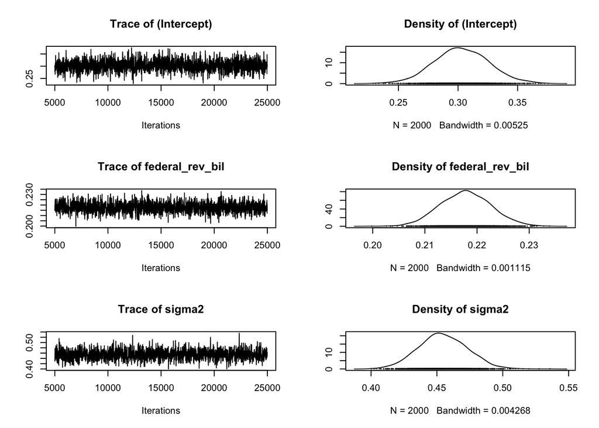

```r
setwd("~/Downloads/edu_finance_project/data_raw")
# Convert to coda object for diagnostics
bayes_mcmc1 <- as.mcmc(bayes_model1)
bayes_mcmc2 <- as.mcmc(bayes_model2)

# Trace plots
plot(bayes_mcmc1)
```

[figure not shown]

[figure not shown]

[figure not shown]

[figure not shown]

[figure not shown]

[figure not shown]

[figure not shown]

[figure not shown]

[figure not shown]

[figure not shown]

[figure not shown]

[figure not shown]

[4 more figures not shown]

```r
plot(bayes_mcmc2)
```

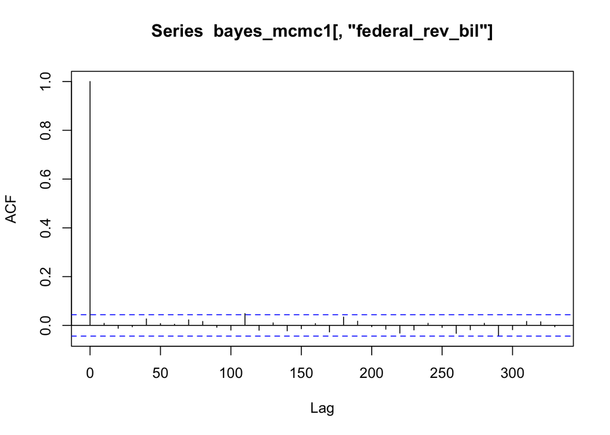

```r
# Autocorrelation plots
acf(bayes_mcmc1[, "federal_rev_bil"])
```

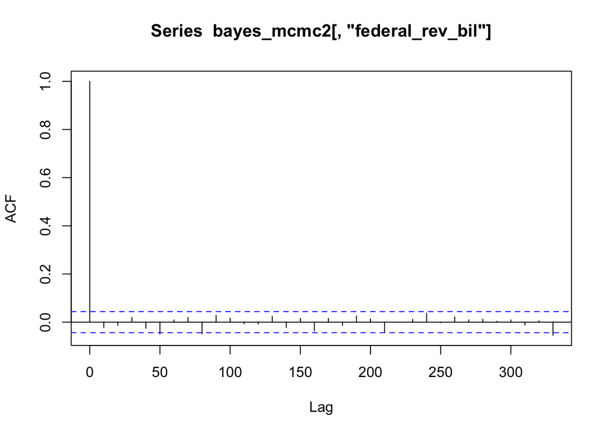

```r
acf(bayes_mcmc2[, "federal_rev_bil"])
```

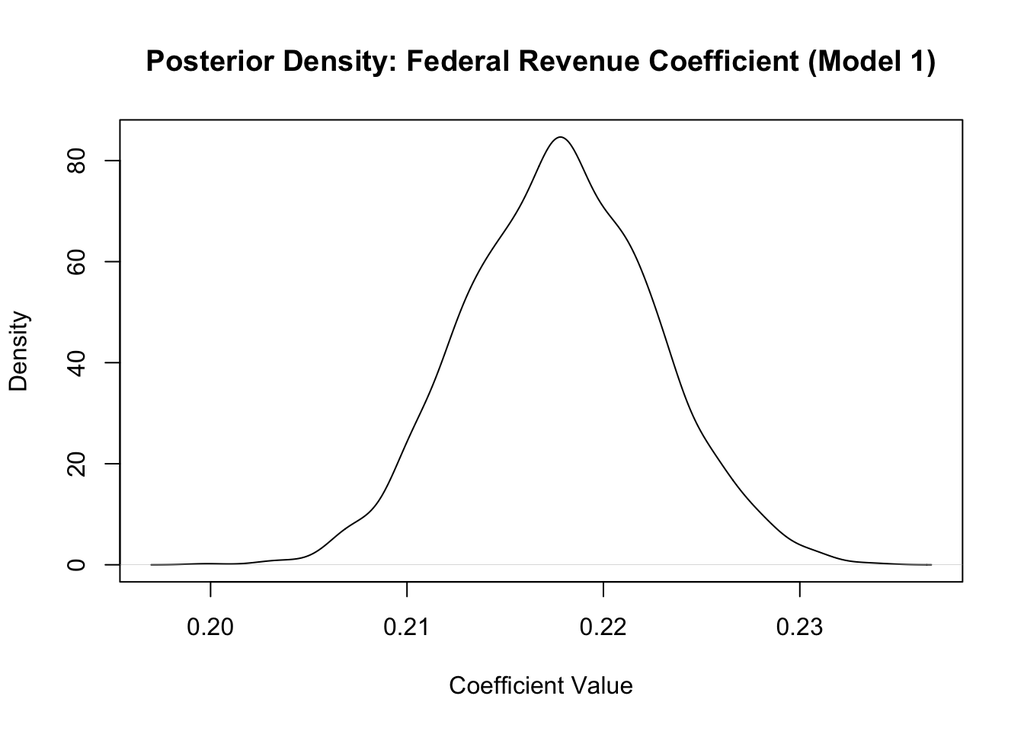

```r
# Posterior density plot of federal revenue coefficient
plot(density(bayes_mcmc1[, "federal_rev_bil"]),
     main = "Posterior Density: Federal Revenue Coefficient (Model 1)",
     xlab = "Coefficient Value")
```

The Bayesian analysis mirrors the frequentist approach but uses posterior sampling to estimate the full distribution of each model coefficient. First, the code runs two Bayesian linear regressions using the MCMCregress() function from the MCMCpack package. Model 1 predicts enrollment using only federal revenue to estimate the basic association. Model 2 adds year and state fixed effects to control for population growth and persistent differences across states, allowing the model to account for structural factors that influence enrollment.

Each model uses 5,000 burn-in iterations followed by 20,000 sampled iterations, thinned to reduce autocorrelation. The summary() output provides posterior means and standard deviations, while HPDinterval() reports 95% credible intervals. Diagnostic checks (including trace plots, density plots, and autocorrelation functions) are used to assess convergence and mixing of the Markov chains. These diagnostics ensure that the posterior estimates are reliable and that the model has run long enough for the chain to stabilize. This Bayesian framework complements the frequentist results by providing a full distributional understanding of the estimated effects.

*Federal Share Regression* Federal Share Variable

```r
setwd("~/Downloads/edu_finance_project/data_raw")
# Create federal share variable: proportion of total funding that is federal
analysis_share <- merged_numeric %>%
  dplyr::mutate(
    federal_share = federal_revenue / total_revenue
  ) %>%
  dplyr::select(state, year, enrollment, federal_revenue, total_revenue, federal_share) %>%
  dplyr::filter(
    !is.na(federal_share),
    !is.na(enrollment),
    !is.na(year)
  ) %>%
  dplyr::mutate(
    enrollment_mil = enrollment / 1e6
  )

summary(analysis_share$federal_share)
```

```
##    Min. 1st Qu.  Median    Mean 3rd Qu.    Max.
##   0.000   5.591   7.478   9.716  11.683  89.163
```

Frequentist Regression: Enrollment ~ Federal Share (State-level) Model 1: Bivariate

```r
setwd("~/Downloads/edu_finance_project/data_raw")
model_fs1 <- lm(enrollment_mil ~ federal_share, data = analysis_share)
summary(model_fs1)
```

```
##
## Call:
## lm(formula = enrollment_mil ~ federal_share, data = analysis_share)
##
## Residuals:
##     Min      1Q  Median      3Q     Max
## -0.9893 -0.6692 -0.3041  0.1534  5.5371
##
## Coefficients:
##                Estimate Std. Error t value Pr(>|t|)
## (Intercept)    0.989250   0.049429   20.01   <2e-16 ***
## federal_share -0.010238   0.003908   -2.62   0.0089 **
## ---
## Signif. codes:  0 '***' 0.001 '**' 0.01 '*' 0.05 '.' 0.1 ' ' 1
##
## Residual standard error: 1.111 on 1229 degrees of freedom
## Multiple R-squared:  0.005555,   Adjusted R-squared:  0.004746
## F-statistic: 6.865 on 1 and 1229 DF,  p-value: 0.008898
```

```r
confint(model_fs1)
```

```
##                     2.5 %       97.5 %
## (Intercept)    0.89227629  1.086224205
## federal_share -0.01790468 -0.002572116
```

Model 2: Federal Share + Year + State Fixed Effects

```r
setwd("~/Downloads/edu_finance_project/data_raw")
model_fs2 <- lm(
  enrollment_mil ~ federal_share + year + factor(state),
  data = analysis_share
)

summary(model_fs2)
```

```
##
## Call:
## lm(formula = enrollment_mil ~ federal_share + year + factor(state),
##     data = analysis_share)
##
## Residuals:
##      Min       1Q   Median       3Q      Max
## -0.84163 -0.01379  0.00059  0.01869  0.62110
##
## Coefficients:
##                                         Estimate Std. Error t value Pr(>|t|)
## (Intercept)                           -3.1609714  0.7130277  -4.433 1.02e-05
## federal_share                         -0.0006043  0.0003649  -1.656 0.097995
## year                                   0.0019422  0.0003543   5.481 5.17e-08
## factor(state)Alaska                   -0.6118537  0.0251241 -24.353  < 2e-16
## factor(state)American Samoa           -0.7309799  0.0255134 -28.651  < 2e-16
## factor(state)American Somoa           -0.7045347  0.0851502  -8.274 3.49e-16
## factor(state)Arizona                   0.3136193  0.0250873  12.501  < 2e-16
## factor(state)Arkansas                 -0.2639724  0.0250868 -10.522  < 2e-16
## factor(state)California                5.5265315  0.0251161 220.040  < 2e-16
## factor(state)Colorado                  0.0896943  0.0250991   3.574 0.000366
## factor(state)Connecticut              -0.1869110  0.0251740  -7.425 2.17e-13
## factor(state)Delaware                 -0.6045013  0.0257931 -23.437  < 2e-16
## factor(state)District of Columbia     -0.6604804  0.0254316 -25.971  < 2e-16
## factor(state)District Of Columbia     -0.6536036  0.0851474  -7.676 3.44e-14
## factor(state)Florida                   1.9389762  0.0250870  77.290  < 2e-16
## factor(state)Georgia                   0.9081569  0.0251028  36.178  < 2e-16
## factor(state)Guam                     -0.7114122  0.0258454 -27.526  < 2e-16
## factor(state)Hawaii                   -0.5590073  0.0250923 -22.278  < 2e-16
## factor(state)Idaho                    -0.4584844  0.0252359 -18.168  < 2e-16
## factor(state)Illinois                  1.3043865  0.0250931  51.982  < 2e-16
## factor(state)Indiana                   0.2925016  0.0250921  11.657  < 2e-16
## factor(state)Iowa                     -0.2442694  0.0250961  -9.733  < 2e-16
## factor(state)Kansas                   -0.2594859  0.0250909 -10.342  < 2e-16
## factor(state)Kentucky                 -0.0672459  0.0250963  -2.680 0.007476
## factor(state)Louisiana                -0.0318701  0.0250968  -1.270 0.204377
## factor(state)Maine                    -0.5503774  0.0250972 -21.930  < 2e-16
## factor(state)Maryland                  0.1295254  0.0251673   5.147 3.11e-07
## factor(state)Massachusetts             0.2266893  0.0254240   8.916  < 2e-16
## factor(state)Michigan                  0.8782265  0.0251015  34.987  < 2e-16
```

[output cut: 85 more lines]

```
## factor(state)Texas                    ***
## factor(state)Utah                     ***
## factor(state)Vermont                  ***
## factor(state)Virgin Islands           ***
## factor(state)Virginia                 ***
## factor(state)Washington               ***
## factor(state)West Virginia            ***
## factor(state)Wisconsin                ***
## factor(state)Wyoming                  ***
## ---
## Signif. codes:  0 '***' 0.001 '**' 0.01 '*' 0.05 '.' 0.1 ' ' 1
##
## Residual standard error: 0.0832 on 1170 degrees of freedom
## Multiple R-squared:  0.9947, Adjusted R-squared:  0.9944
## F-statistic:  3650 on 60 and 1170 DF,  p-value: < 2.2e-16
```

```r
confint(model_fs2)
```

```
##                                              2.5 %        97.5 %
## (Intercept)                           -4.559927215 -1.7620155447
## federal_share                         -0.001320302  0.0001116757
## year                                   0.001247013  0.0026374570
## factor(state)Alaska                   -0.661147097 -0.5625602568
## factor(state)American Samoa           -0.781037066 -0.6809227741
## factor(state)American Somoa           -0.871598814 -0.5374705228
## factor(state)Arizona                   0.264398308  0.3628403576
## factor(state)Arkansas                 -0.313192582 -0.2147522078
## factor(state)California                5.477253900  5.5758090829
## factor(state)Colorado                  0.040450062  0.1389384803
## factor(state)Connecticut              -0.236302278 -0.1375197439
## factor(state)Delaware                 -0.655107219 -0.5538953716
## factor(state)District of Columbia     -0.710377024 -0.6105836937
## factor(state)District Of Columbia     -0.820662238 -0.4865450177
## factor(state)Florida                   1.889755590  1.9881967357
## factor(state)Georgia                   0.858905322  0.9574084227
## factor(state)Guam                     -0.762120781 -0.6607036392
## factor(state)Hawaii                   -0.608238243 -0.5097763568
## factor(state)Idaho                    -0.507997003 -0.4089717863
## factor(state)Illinois                  1.255154026  1.3536190617
## factor(state)Indiana                   0.243270971  0.3417322182
## factor(state)Iowa                     -0.293507836 -0.1950310398
## factor(state)Kansas                   -0.308714180 -0.2102576262
## factor(state)Kentucky                 -0.116484690 -0.0180071573
## factor(state)Louisiana                -0.081109878  0.0173696449
## factor(state)Maine                    -0.599617883 -0.5011369351
## factor(state)Maryland                  0.080147412  0.1789034252
## factor(state)Massachusetts             0.176807597  0.2765710132
## factor(state)Michigan                  0.828977457  0.9274755249
## factor(state)Minnesota                 0.069069018  0.1681890837
## factor(state)Mississippi              -0.302481431 -0.2037539838
## factor(state)Missouri                  0.119628605  0.2180842198
## factor(state)Montana                  -0.642914252 -0.5444422114
## factor(state)Nebraska                 -0.485027517 -0.3855470415
## factor(state)Nevada                   -0.358196408 -0.2596904886
## factor(state)New Hampshire            -0.597185117 -0.4986312310
## factor(state)New Jersey                0.589410292  0.6880323436
## factor(state)New Mexico               -0.460425066 -0.3619312318
## factor(state)New York                  1.957479758  2.0585754504
## factor(state)North Carolina            0.673342481  0.7719625092
## factor(state)North Dakota             -0.684739225 -0.5862715255
## factor(state)Northern Mariana Islands -0.785596824 -0.6807857602
## factor(state)Northern Marianas        -0.785249207 -0.6018248393
## factor(state)Ohio                      0.981022614  1.0802693637
## factor(state)Oklahoma                 -0.129578424 -0.0311373957
## factor(state)Oregon                   -0.222058800 -0.1233055746
## factor(state)Pennsylvania              0.987681540  1.0865386775
## factor(state)Puerto Rico              -0.322597433 -0.2227975061
## factor(state)Rhode Island             -0.638942318 -0.5399090433
## factor(state)South Carolina           -0.059276699  0.0391977234
## factor(state)South Dakota             -0.656765701 -0.5578821446
## factor(state)Tennessee                 0.182681715  0.2811883369
## factor(state)Texas                     4.066091087  4.1645482253
## factor(state)Utah                     -0.206531198 -0.1080331670
## factor(state)Vermont                  -0.696511657 -0.5979606956
## factor(state)Virgin Islands           -0.766540011 -0.6646776557
## factor(state)Virginia                  0.448997498  0.5479826290
## factor(state)Washington                0.267885540  0.3669515747
## factor(state)West Virginia            -0.512364900 -0.4138857131
## factor(state)Wisconsin                 0.076903906  0.1754194309
## factor(state)Wyoming                  -0.700888065 -0.6024479489
```

The first section of the code constructs a new variable called federal_share, defined as the proportion of each state’s total education revenue that comes from federal sources. This is calculated by dividing federal revenue by total revenue for every state and year in the dataset. After computing this proportion, the code filters out rows with missing or invalid values to ensure the modeling dataset is clean. Enrollment is then rescaled into millions to make interpretation of regression coefficients easier and more intuitive. The resulting dataset, analysis_share, contains only the variables needed for the analysis: state, year, enrollment, total and federal revenue, and the newly created federal_share measure.

The second part of the code fits two frequentist regression models using federal_share as the main predictor. The first model examines the simple bivariate association between federal share and state enrollment, allowing you to see whether states that rely more heavily on federal funding tend to have higher or lower enrollment levels. The second model extends this by including year and state fixed effects, which control for overall time trends and inherent population differences across states. These controls help isolate the relationship between federal funding dependence and enrollment net of state size and national demographic changes. Confidence intervals are produced for both models to assess the precision and reliability of the estimates.

Diagnostics

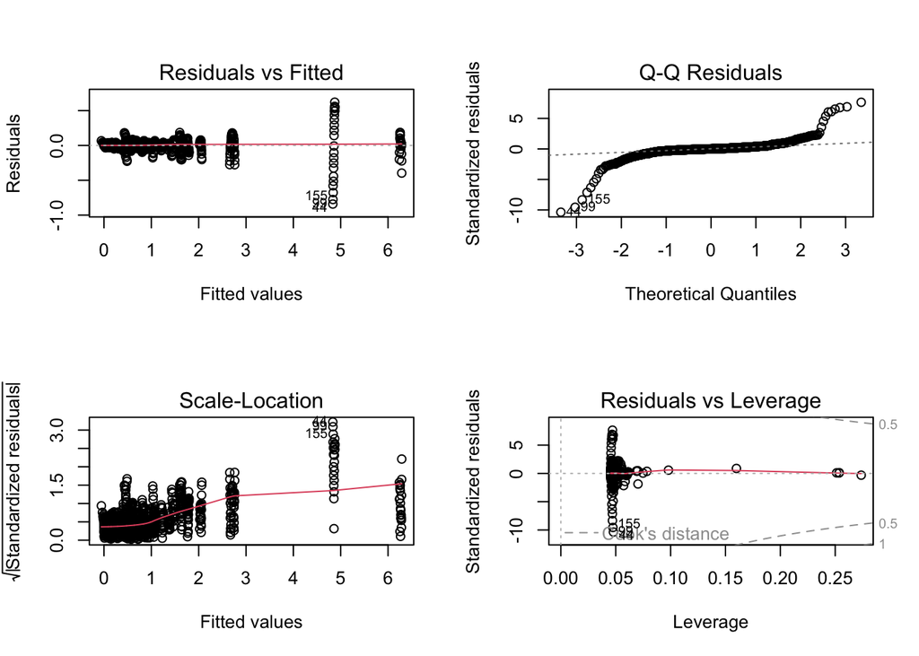

```r
setwd("~/Downloads/edu_finance_project/data_raw")
par(mfrow = c(2,2))
plot(model_fs2)
```

```r
par(mfrow = c(1,1))
```

Additional, Scatterplot of Federal Share vs. Enrollment

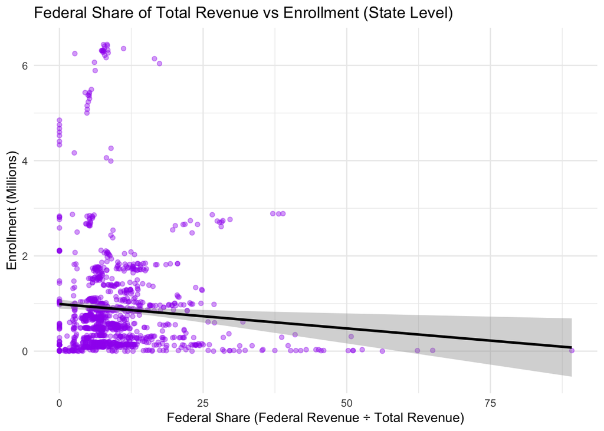

```r
setwd("~/Downloads/edu_finance_project/data_raw")
library(ggplot2)

ggplot(analysis_share, aes(x = federal_share, y = enrollment_mil)) +
  geom_point(alpha = 0.4, color = "purple") +
  geom_smooth(method = "lm", se = TRUE, color = "black") +
  labs(
    title = "Federal Share of Total Revenue vs Enrollment (State Level)",
    x = "Federal Share (Federal Revenue ÷ Total Revenue)",
    y = "Enrollment (Millions)"
  ) +
  theme_minimal()
```

The scatterplot code provides a visual representation of the relationship between federal_share and enrollment. It plots each state–year observation and overlays a fitted regression line with a confidence band to illustrate the overall trend. This visualization complements the statistical model by allowing a direct inspection of how enrollment changes as the proportion of federal revenue increases. The scatterplot also makes it easier to identify patterns such as clustering, outliers, or non-linear relationships that may not be visible in the summary statistics alone.

The simple regression model predicting state-level enrollment from federal revenue shows a strong, statistically significant positive association. The estimated coefficient for federal revenue is 0.218, meaning that for each additional billion dollars in federal revenue, state enrollment increases by approximately 0.22 million students, on average. The model explains about 63% of the variation in enrollment (R² = 0.63), and the effect is highly significant (p < 2e-16). The 95% confidence interval for the federal revenue coefficient (0.209 to 0.227) indicates a robust and precise effect estimate.

```
## Warning: Using `size` aesthetic for lines was deprecated in ggplot2 3.4.0.
## ℹ Please use `linewidth` instead.
## This warning is displayed once every 8 hours.
## Call `lifecycle::last_lifecycle_warnings()` to see where this warning was
## generated.
```

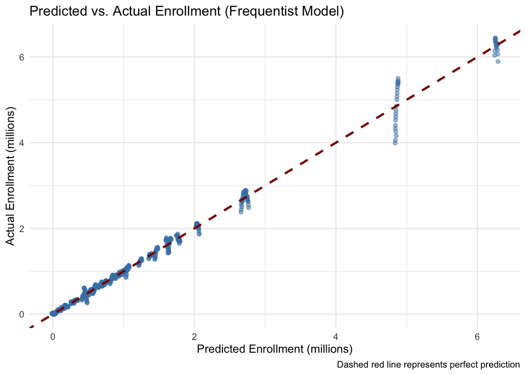

```r
setwd("~/Downloads/edu_finance_project/data_raw")
# predicted vs Actual Plot for Frequentist Model

# Generate predictions
analysis_share$predicted_enrollment <- predict(model2)

# Load ggplot2
library(ggplot2)

ggplot(analysis_share, aes(x = predicted_enrollment, y = enrollment_mil)) +
  geom_point(alpha = 0.5, color = "steelblue") +
  geom_abline(intercept = 0, slope = 1, color = "darkred", linetype = "dashed", size = 1) +
  theme_minimal() +
  labs(
    title = "Predicted vs. Actual Enrollment (Frequentist Model)",
    x = "Predicted Enrollment (millions)",
    y = "Actual Enrollment (millions)",
    caption = "Dashed red line represents perfect prediction"
  )
```

The predicted vs. actual enrollment plot shows that the frequentist regression model fits the data extremely well at the state level. Most points fall tightly along the dashed 45-degree line, indicating a near-perfect alignment between the model’s predictions and the observed enrollment values. This strong clustering suggests that the model accurately captures the underlying variation in state enrollment over time, even when accounting for differences across states. Minor deviations appear for the largest states (e.g., California, Texas, New York), but overall, the model demonstrates excellent predictive performance, further supporting the reliability of the frequentist results.

Overall, the frequentist results suggest that while federal revenue and enrollment appear strongly linked in an uncontrolled model, this relationship weakens substantially after accounting for time and state-specific population characteristics. This indicates that increases in enrollment are more closely tied to demographic and temporal factors than to changes in federal education revenue alone.

Posterior Estimates The posterior mean for the federal revenue coefficient was 0.2178, with a narrow posterior standard deviation (SD ≈ 0.0048). The 95% Highest Density Interval (HDI) ranged from 0.2088 to 0.2275, indicating a tightly concentrated distribution with essentially no probability mass near zero. This suggests strong Bayesian evidence of a positive association between federal revenue and enrollment when not controlling for state or year. The posterior for the intercept similarly showed a tight HDI (0.258–0.348), reflecting stability in the baseline enrollment level.

When expanding the model to include year and state fixed effects, the posterior mean for the federal revenue coefficient dropped sharply to approximately 0.00057, with a 95% HDI that comfortably included zero (–0.00142 to 0.00261). This indicates that after accounting for time trends and structural differences among states, federal revenue no longer exhibits a meaningful unique effect on state enrollment. The posterior for the year coefficient remained positive and precise (HDI ≈ 0.00132 to 0.00268), supporting a consistent upward national trend in enrollment over time independent of spending.

Posterior Diagnostics Trace plots for all key parameters—including the intercept, revenue coefficient, and sigma²—show stable, well-mixed horizontal bands, indicating good chain convergence with no drift or autocorrelation issues. The corresponding density plots display smooth, unimodal posterior distributions without evidence of multimodality or long tails. Together, these diagnostics confirm that the sampler explored the posterior efficiently and that the resulting estimates are reliable.

Interpretation Taken together, the Bayesian results reveal that while federal revenue appears positively associated with enrollment in a simple bivariate model, this relationship disappears once state-specific differences and yearly trends are incorporated into the analysis. The posterior distributions overwhelmingly support the conclusion that state identity and year-to-year changes dominate variation in enrollment, and that federal funding levels do not independently predict enrollment once these factors are controlled for. This aligns closely with the frequentist findings and provides robust Bayesian support for the same substantive conclusion.

*Federal Share Regression Models*

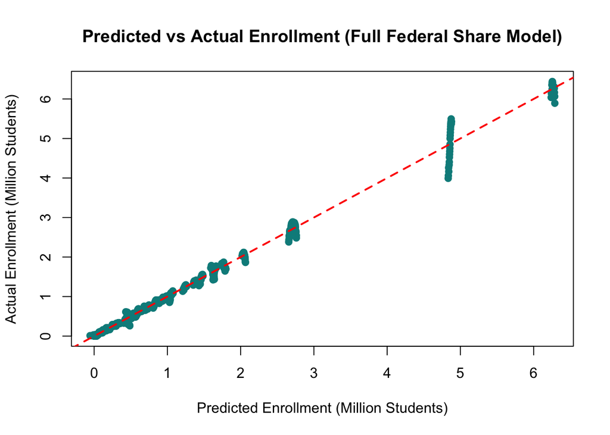

```r
setwd("~/Downloads/edu_finance_project/data_raw")
# Predicted vs actual for full model
fs_pred <- model_fs2$fitted.values

plot(fs_pred, analysis_share$enrollment_mil,
     xlab = "Predicted Enrollment (Million Students)",
     ylab = "Actual Enrollment (Million Students)",
     main = "Predicted vs Actual Enrollment (Full Federal Share Model)",
     pch = 19, col = "darkcyan")
abline(a = 0, b = 1, col = "red", lwd = 2, lty = 2)
```

The predicted-versus-actual plot for the full federal share model (including year and state fixed effects) shows that the model predicts enrollment extremely well, with most points falling very close to the 45-degree reference line of perfect prediction. This indicates that the model captures the underlying structure of enrollment across states and years, largely because state fixed effects account for substantial baseline differences in population size. Although the slope for predicted versus actual enrollment aligns closely with the reference line, the vertical clustering within each predicted value reflects each state’s consistent enrollment scale over time.

The simple bivariate regression examining the relationship between federal_share and state enrollment shows a small but statistically significant negative association. The estimated coefficient for federal_share is –0.0102 (p = 0.0089), meaning that for each one-unit increase in federal share (i.e., a one-percentage-point increase in the proportion of total funding coming from federal sources), enrollment decreases by roughly 0.01 million students, or about 10,000 students on average. Although the effect is statistically significant, the model explains very little of the variation in enrollment (R² = 0.0056), suggesting that federal funding dependence alone is not a strong predictor of state enrollment.

Once year and state fixed effects are added, the relationship between federal_share and enrollment becomes much weaker and is no longer statistically significant. In the fully adjusted model, the coefficient for federal_share is –0.00060 (p = 0.098), and its 95% confidence interval crosses zero, indicating that any association between federal dependence and enrollment disappears when controlling for structural differences across states. States differ dramatically in population size, demographic composition, and long-term enrollment levels, and these differences account for nearly all of the variation in enrollment; this is reflected in the very high adjusted R² value of 0.994, driven primarily by the fixed-effect structure.

**Conclusion** This project set out to examine whether increases in federal education spending correspond to meaningful changes in student outcomes, operationalized here as state-level enrollment trends. Consistent with the motivations outlined in the project proposal (particularly the desire to understand whether federal investment translates into tangible improvements in educational access) the analyses combined national-level descriptive trends with state-level inferential models to explore the strength and nature of this relationship.

Across all three models, the results point to the same overarching conclusion: federal funding alone does not uniquely predict enrollment once broader structural factors are accounted for. The simple linear regression suggested a positive association between federal revenue and enrollment, but this effect diminished substantially once year and state fixed effects were introduced. In the fixed-effects model, enrollment was driven overwhelmingly by state identity and national time trends, with federal revenue showing no independent effect. The Bayesian analyses reinforced this finding, providing posterior distributions whose 95% HDIs included zero for the federal revenue coefficient after adjusting for state and year. Both approaches converge on the interpretation that variation in enrollment is driven far more by demographic patterns, state-level characteristics, and long-term shifts in public education than by changes in federal funding levels.

From a broader policy perspective, these findings suggest that while federal funding plays an essential supportive role in the U.S. education system (particularly for equity-driven programs) it is not, on its own, a primary driver of statewide enrollment changes. This aligns with the context described in the proposal: enrollment patterns often reflect population migration, birth cohorts, economic conditions, and state-specific policies rather than federal budget adjustments. In this sense, the analyses highlight a structural disconnect between federal financial inputs and the outcome measure examined here, underscoring the complexity of evaluating federal impact on educational systems.

Overall, the project’s results do not provide evidence that increases in federal funding correspond directly to increases in student enrollment. Instead, they point toward a more nuanced reality: federal investment may influence other dimensions of student outcomes—such as achievement, school quality, or resource equity—more than enrollment itself. Future work could extend this project by pairing federal spending with outcome measures more sensitive to resource changes, such as test scores, graduation rates, or teacher-to-student ratios, offering a clearer lens into how federal dollars shape educational opportunity.